# Advanced Remote Sensing Lab 10: Advanced classification algorithms

Victor Gutierrez (victorhugo@temple.edu)

### Lab due

April 06 2021

### Goals

1. To become familiar with the characteristics and use of optical data from the Sentinel 2 mission.
2. To become familiar with the parameterization of advanced algorithms for image classification and their performance.

### Total score

The lab counts for up to 3 points towards the final grade of the course.

Have fun!

### Lab instructions

#### 1. Upload and pre-process sentinel data.

Click on the following link to become familiar with the Sentinel 2 image collection: https://developers.google.com/earth-engine/datasets/catalog/COPERNICUS_S2

Copy and paste the function below in your script. You will use the function to mask clouds and cloud shadows based on the QA layer available in the sentinel data collection. This is analogue to the function that we used to mask clouds and cloud shadows in Lab 5.

```javascript
// function to mask clouds
function maskS2clouds(image) {
  var qa = image.select('QA60');

  // Bits 10 and 11 are clouds and cirrus, respectively.
  var cloudBitMask = 1 << 10;
  var cirrusBitMask = 1 << 11;

  // Both flags should be set to zero, indicating clear conditions.
  var mask = qa.bitwiseAnd(cloudBitMask).eq(0)
      .and(qa.bitwiseAnd(cirrusBitMask).eq(0));

  return image.updateMask(mask).divide(10000);
}
```

Navigate in the map view to the area near to Amsterdam. Based on what you learned in labs 5 and 6, draw a polygon defining your study area and name it “StudyArea”. Then load the Sentinel 2 image collection (surface reflectance) and use the polygon to apply spatial filter. Select a time range to also apply temporal filter.

```javascript
var S2 =ee.ImageCollection("COPERNICUS/S2_SR")
        .filterBounds(StudyArea)
        .filter(ee.Filter.calendarRange(2019,2020,'year'))
        .filter(ee.Filter.calendarRange(153,244, 'day_of_year'))
        //.filterDate('2017-03-20', '2017-04-09')
        //.filter(ee.Filter.lt('CLOUDY_PIXEL_PERCENTAGE', 20))
        .map(maskS2clouds);
```

Select a subset of bands that you will use for classification. Then produce a composite representing the median value for each pixel in the time series and add it to the map view.

```javascript
var bands =['B2', 'B3', 'B4', 'B5', 'B6', 'B7', 'B8', 'B8A', 'B9', 'B11', 'B12'];

var S2_sel= S2.select(bands);
print(S2_sel, "S2_sel");

var count17 = S2_sel.size();
print('Count of S2_SA_2020: ', count17);

var S2_sel_med= S2_sel.median();
print (S2_sel_med, "S2_sel_med")

// define visualization parameters
var rgbVis = {
  min: 0.0,
  max: 0.5,
  bands: ['B4', 'B3', 'B2'],
  gamma: 1.6,
};

Map.centerObject(StudyArea, 11);
Map.addLayer(S2_sel_med, rgbVis, 'RGB');
```

#### 2. Training data collection.

Select click on the “+ new layer” button (blue circle in image below) and collect points for a second class of interest. Repeat the process for all classes.

Click on the wheel on front of each layer (yellow circle in image below).

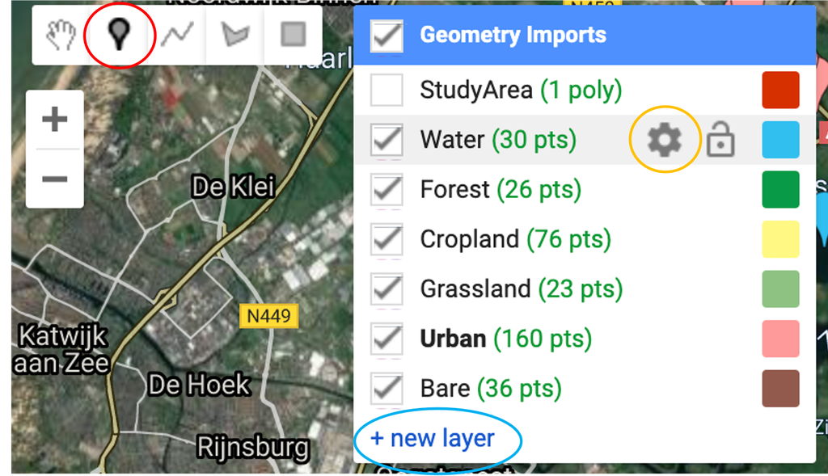

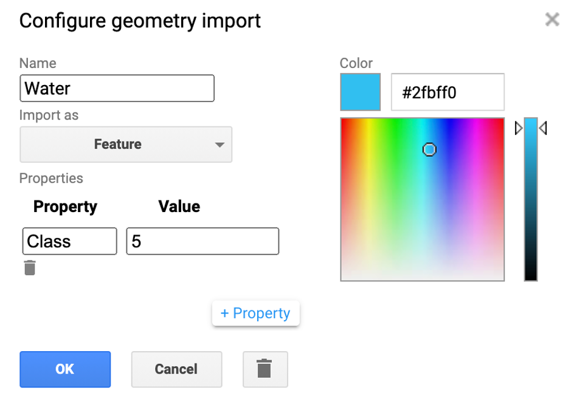

Add all the feature classes into a feature collection. Use the feature collection to extract the reflectance data that corresponds to each marked location.

```javascript
// Collect points for classification
var calib = ee.FeatureCollection([Bare, Cropland, Forest, Grassland, Urban, Water]);
print(calib,"calib")

// Overlay the points on the imagery to get training.
var training = S2_sel_med.select(bands).sampleRegions({
  collection: calib,
  properties: ['Class'],
  scale: 30
});

print(training, "training")
```

#### 3. Produce classified maps with different classification algorithms

```javascript
var cart = ee.Classifier.smileCart().train(training, "Class", bands);
print(cart, "cart")

var rf = ee.Classifier.smileRandomForest(10)
    .train({
      features: training,
      classProperty: 'Class',
      inputProperties: bands
    });
print(rf, "rf")

var gtb = ee.Classifier.smileGradientTreeBoost(10)
    .train({
      features: training,
      classProperty: 'Class',
      inputProperties: bands
    });
print(gtb, "gtb")

var naive = ee.Classifier.smileNaiveBayes()
    .train({
      features: training,
      classProperty: 'Class',
      inputProperties: bands
    });
print(naive, "naive")

var svm = ee.Classifier.libsvm({
  kernelType: 'RBF',
  gamma: 0.5,
  cost: 10})
    .train({
      features: training,
      classProperty: 'Class',
      inputProperties: bands,

    });
print(svm, "svm")
```

Use the trained algorithms to classify the image

```javascript
var cart_class = S2_sel_med.select(bands).classify(cart);
print(cart_class, "cart_class")

var rf_class = S2_sel_med.classify(rf)
print(rf_class, "rf_class")

var gtb_class = S2_sel_med.select(bands).classify(gtb);
print(gtb_class, "gtb")

var naive_class = S2_sel_med.select(bands).classify(naive);
print(naive_class, "naive")

var svm_class = S2_sel_med.select(bands).classify(svm);
print(svm_class, "svm_class")
```

Add the classified maps to the map view and compare their performance visually

```javascript
var Palette = ['92584d',  'fff882', '099a46', '8ec283', 'ff9a9a', '2fbff0'];

Map.addLayer(cart_class, {palette: Palette, min: 0, max: 4}, 'cart_class')
Map.addLayer(rf_class, {palette: Palette, min: 0, max: 4}, 'rf_class')
Map.addLayer(gtb_class, {palette: Palette, min: 0, max: 4}, 'gtb_class')
Map.addLayer(naive_class, {palette: Palette, min: 0, max: 4}, 'naive_class')
Map.addLayer(svm_class, {palette: Palette, min: 0, max: 4}, 'svm_class')
```

### Homework

Follow the lab instructions to produce land cover classifications for the area where you are planning to work for your final project. Fill up this form for your report: https://forms.office.com/Pages/ResponsePage.aspx?id=74FucSK1c0SOMRC9Asz25dmnkCS0Q29AsedCc0cCybpUN0tZWE04MEgzVDI0UVM5UzQ0R0lNVldOSy4u

#### Sources

https://developers.google.com/earth-engine/guides/classification